# Climatic niche differences betwqeen colour morphs

Fabian C. Salgado-Roa

2024-02-12

# Analysis of climatic niche divergence of color morphs

load libraries

```r
library(sf)
library("rworldmap")
library(tidyverse)
```

load inputs

```r
load("input_niche_tmp_analyses.rda")
map_world <- getMap(resolution = "high")
aus_map<-st_as_sf(map_world[which(map_world$ISO3=="AUS"),])
```

## range maps phenotypes

```r
## Nonmelanic range
# Convert nonmelanic_geoThin to sf object, set coordinates, and transform to appropriate CRS
nonmelanic_points <- st_as_sf(nonmelanic_geoThin, coords = c("Longitude", "Latitude"), crs = 4326) %>% st_transform(3112)

# Create rangeMap for nonmelanic points: buffer, union, intersect with aus_map, and transform to desired CRS
rangeMap_nonmelanic <- st_buffer(nonmelanic_points, dist = 100000) %>%
  st_union() %>%
  st_intersection(aus_map %>% st_transform(3112)) %>%
  st_transform(4326)

## Melanic range
# Convert melanic_geoThin to sf object, set coordinates, and transform to appropriate CRS
melanic_points <- st_as_sf(melanic_geoThin, coords = c("Longitude", "Latitude"), crs = 4326) %>% st_transform(3112)

# Create rangeMap for melanic points: buffer, union, intersect with aus_map, and transform to desired CRS
rangeMap_melanic <- st_buffer(melanic_points, dist = 100000) %>%
  st_union() %>%
  st_intersection(aus_map %>% st_transform(3112)) %>%
  st_transform(4326)

## Orange range
# Convert orange_geoThin to sf object, set coordinates, and transform to appropriate CRS
orange_points <- st_as_sf(orange_geoThin, coords = c("Longitude", "Latitude"), crs = 4326) %>% st_transform(3112)

# Create rangeMap for orange points: buffer, union, intersect with aus_map, and transform to desired CRS
rangeMap_orange <- st_buffer(orange_points, dist = 100000) %>%
  st_union() %>%
  st_intersection(aus_map %>% st_transform(3112)) %>%
  st_transform(4326)

# Combine rangeMaps for all phenotypes into a single sf object and add phenotype labels
rangeMap_phenotypes <- st_sf(c(rangeMap_nonmelanic, rangeMap_melanic, rangeMap_orange)) %>%
            mutate(phenotype = c("nonmelanic", "melanic", "orange"))
```

## Create ecoregion background

```r
# Read the ecoregions shapefile
ecoregions <- st_read("Ecoregions2017.shp")
# Load the sf library for spatial operations
library(sf)

# Cast ecoregions to polygons and transform to the desired CRS (Coordinate Reference System)
cast_eco <- st_cast(ecoregions, "POLYGON") %>% st_transform(3112)

# Intersect phenotypes and ecoregions to identify overlapping areas
amix_ecoregions <- st_intersects(x = st_cast(ecoregions, "POLYGON") %>% st_transform(3112),
                                  y = rangeMap_phenotypes %>% st_transform(3112))
amix_ecoregions <- amix_ecoregions %>% as.data.frame() %>% distinct(`row.id`) %>% pull()

# Extract ecoregions intersecting with phenotypes based on the intersecting areas identified
amix_ecoregions <- cast_eco[amix_ecoregions,] %>% group_by(OBJECTID) %>% summarise()

# Identify regions intersecting with nonmelanic phenotypes
nonmelanic_regions <- st_intersects(amix_ecoregions, filter(.data = rangeMap_phenotypes %>% st_transform(3112),
                                                             phenotype == "nonmelanic")) %>%
                      as.data.frame() %>%
                      distinct(`row.id`) %>%
                      pull()

# Identify regions intersecting with melanic phenotypes
melanic_regions <- st_intersects(amix_ecoregions, filter(.data = rangeMap_phenotypes %>% st_transform(3112),
                                                          phenotype == "melanic")) %>%
                    as.data.frame() %>%
                    distinct(`row.id`) %>%
                    pull()

# Identify regions intersecting with orange phenotypes
orange_regions <- st_intersects(amix_ecoregions, filter(.data = rangeMap_phenotypes %>% st_transform(3112),
                                                          phenotype == "orange")) %>%
                    as.data.frame() %>%
                    distinct(`row.id`) %>%
                    pull()

# Find intersections between different phenotype regions
non_melanic_inter <- intersect(nonmelanic_regions, melanic_regions)
intersect_all_morphs <- intersect(non_melanic_inter, orange_regions)

# Update ecoregions with phenotype information based on the intersections
amix_ecoregions <- amix_ecoregions %>%
                      mutate(phenotype = case_when(row_number() %in% intersect_all_morphs ~ "all",
                                                   row_number() %in% intersect(nonmelanic_regions, melanic_regions) ~ "melanic_nonmelanic",
                                                   row_number() %in% intersect(nonmelanic_regions, orange_regions) ~ "orange_nonmelanic",
                                                   row_number() %in% intersect(melanic_regions, orange_regions) ~ "orange_melanic",
                                                   row_number() %in% melanic_regions ~ "melanic",
                                                   row_number() %in% orange_regions ~ "orange",
                                                   row_number() %in% nonmelanic_regions ~ "nonmelanic"))

# Transform ecoregions back to the original projection
amix_ecoregions <- amix_ecoregions %>% st_transform(4326)
```

Visualize background

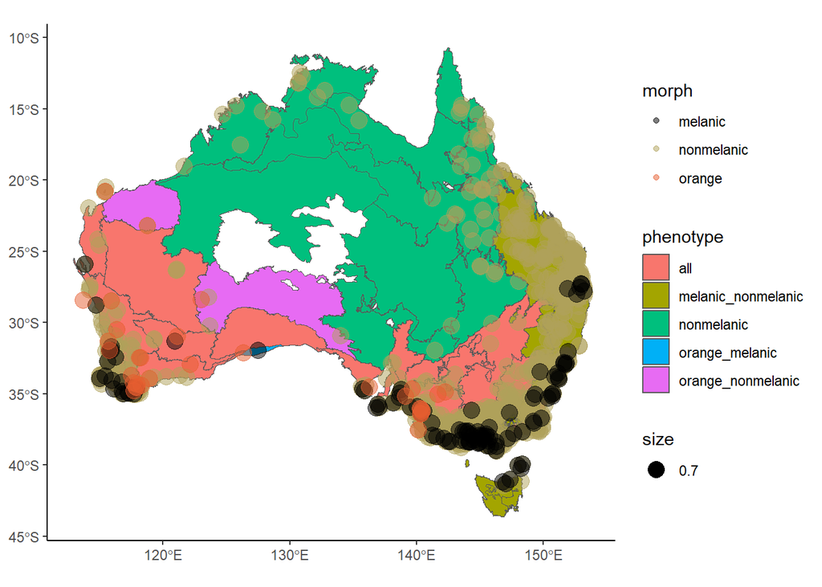

```r
#colours
o_col<-"#e65d2f"
w_col<-"#AFA15A"
b_col<-"black"

amix_points<-rbind(nonmelanic_points,melanic_points,orange_points)

amix_ecoregions %>%
  ggplot() +
  geom_sf(aes(fill = phenotype)) +
  geom_sf(data = amix_points,aes(color = morph,size=0.7)) +
  scale_color_manual(values = alpha(c(b_col, w_col, o_col),0.5))+
  theme_classic()
```

## Defining each color morph’s modelling domain

The modeling area was characterized as the terrestrial ecoregions where species ranges overlap. Gathering environmental data from 10,000 points would provide an adequate sample size.

*nonmelanic_c* is the environment in sampled on occurrence points of the nonmelanic morph (Prob = 1) and on random background points (Prob = 0).

Load chelsa variables

```r
library(terra)

chelsa_variables <- raster::stack(list.files(path = "chelsea", pattern = ".tif", full.names = TRUE))

# Extract variable names from file names
names_variables <- list.files(path = "chelsea", pattern = ".tif$", full.names = TRUE) %>%
                    str_match(pattern = "\\w+.tif$") %>%
                    gsub(pattern = ".tif", replacement = "") %>%
                    as.vector()

# Assign descriptive names to the raster layers
names(chelsa_variables) <- paste0("chelsa_", names_variables)

chelsa_variables$chelsa_pr<-log(chelsa_variables$chelsa_pr)
```

Extract background points per morph

```r
# Load the dismo package for species distribution modeling
library(dismo)

# Create a dataset for nonmelanic species
# Generate random background points within ecoregions intersecting with nonmelanic phenotypes
nonmelanic_bg <- randomPoints(mask(chelsa_variables[[1]], filter(.data = amix_ecoregions, phenotype %in% c("all", "melanic_nonmelanic", "nonmelanic", "orange_nonmelanic"))), n=10000)

# Combine coordinates of nonmelanic species occurrences with background points
nonmelanic_c <- rbind(mutate(nonmelanic_geoThin[, c("Longitude", "Latitude")], Prob = 1),
                      mutate(rename(data.frame(nonmelanic_bg), Longitude = x, Latitude = y), Prob = 0))

# Extract environmental variables for nonmelanic species occurrences and background points
nonmelanic_c <- cbind(nonmelanic_c, raster::extract(chelsa_variables, nonmelanic_c[, c("Longitude", "Latitude")])) %>%
                 na.omit()

# Create a dataset for melanic species
# Generate random background points within ecoregions intersecting with melanic phenotypes
melanic_bg <- randomPoints(mask(chelsa_variables[[1]], filter(.data = amix_ecoregions, phenotype %in% c("all", "melanic", "melanic_nonmelanic", "orange_melanic"))), 10000)

# Combine coordinates of melanic species occurrences with background points
melanic_c <- rbind(mutate(melanic_geoThin[, c("Longitude", "Latitude")], Prob = 1),
                   mutate(rename(data.frame(melanic_bg), Longitude = x, Latitude = y), Prob = 0))

# Extract environmental variables for melanic species occurrences and background points
melanic_c <- cbind(melanic_c, raster::extract(chelsa_variables, melanic_c[, c("Longitude", "Latitude")])) %>%
              na.omit()

# Create a dataset for orange phenotypes
# Generate random background points within ecoregions intersecting with orange phenotypes
orange_bg <- randomPoints(mask(chelsa_variables[[1]], filter(.data = amix_ecoregions, phenotype %in% c("all", "orange", "orange_nonmelanic", "orange_melanic"))), 10000)

# Combine coordinates of orange phenotype occurrences with background points
orange_c <- rbind(mutate(orange_geoThin[, c("Longitude", "Latitude")], Prob = 1),
                  mutate(rename(data.frame(orange_bg), Longitude = x, Latitude = y), Prob = 0))

# Extract environmental variables for orange phenotype occurrences and background points
orange_c <- cbind(orange_c, raster::extract(chelsa_variables, orange_c[, c("Longitude", "Latitude")])) %>%
            na.omit()
```

## Univariate analysis of climat niche divergence

visualizing climatic niche shift along single environmental variables

### Chelsa data

create data for plotting

```r
plot_data <- mutate(nonmelanic_c,
                    morph = "nonmelanic") %>%
  bind_rows(mutate(melanic_c,
                   morph = "melanic")) %>%
  bind_rows(mutate(orange_c,
                   morph = "orange")) %>%
  pivot_longer(cols = -c("Longitude","Latitude","Prob","morph"),names_to = "variable",values_to = "value") %>%
  mutate(Prob = factor(Prob))
```

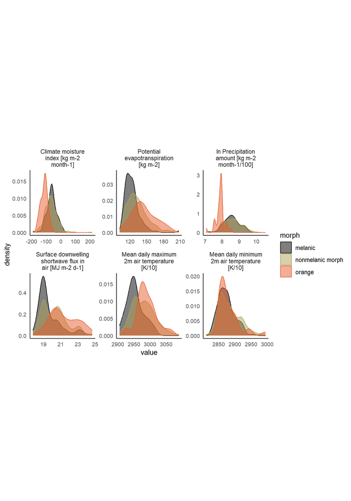

```r
# Define colors for morphs
o_col <- "#e65d2f"  # Orange color
w_col<-"#AFA15A"     # White color
b_col <- "black"     # Black color

# Create a vector of colors
colours <- c(b_col, w_col, o_col)

# Plotting using ggplot
ggplot() +
  # Add density plot for 'Prob' equal to 1
  geom_density(data = filter(plot_data, Prob == "1"),
               aes(x = value, color = morph,fill=morph)) +

  # Facet wrapping by 'variable' with customized labels
  facet_wrap(vars(fct_relevel(variable)),
             scales = "free",
             labeller = as_labeller(c(
               "chelsa_cmi" = str_wrap("Climate moisture index [kg m-2 month-1]", width = 20),
               "chelsa_pet" = str_wrap("Potential evapotranspiration [kg m-2]", width = 20),
               "chelsa_pr" = str_wrap("ln Precipitation amount [kg m-2 month-1/100]", width = 20),
               "chelsa_rsds" = str_wrap("Surface downwelling shortwave flux in air [MJ m-2 d-1]", width = 20),
               "chelsa_tasmax" = str_wrap("Mean daily maximum 2m air temperature [K/10]", width = 20),
               "chelsa_tasmin" = str_wrap("Mean daily minimum 2m air temperature [K/10]", width = 20)))) +

  # Manually set color values and labels
  scale_color_manual(values = colours,labels = c("melanic", "nonmelanic morph", "orange")) +
  scale_fill_manual(values = alpha(colours,0.5),labels = c("melanic", "nonmelanic morph", "orange"))+

  # Customize theme
  theme_classic() +
    theme(
    title = element_text(size = 10),
    strip.background = element_blank(),
    panel.background = element_blank(),
    panel.grid = element_blank(),
    axis.text = element_text(size = 8),
    axis.ticks = element_blank(),
    aspect.ratio = 1
  )
```

We can compare this output with the background points

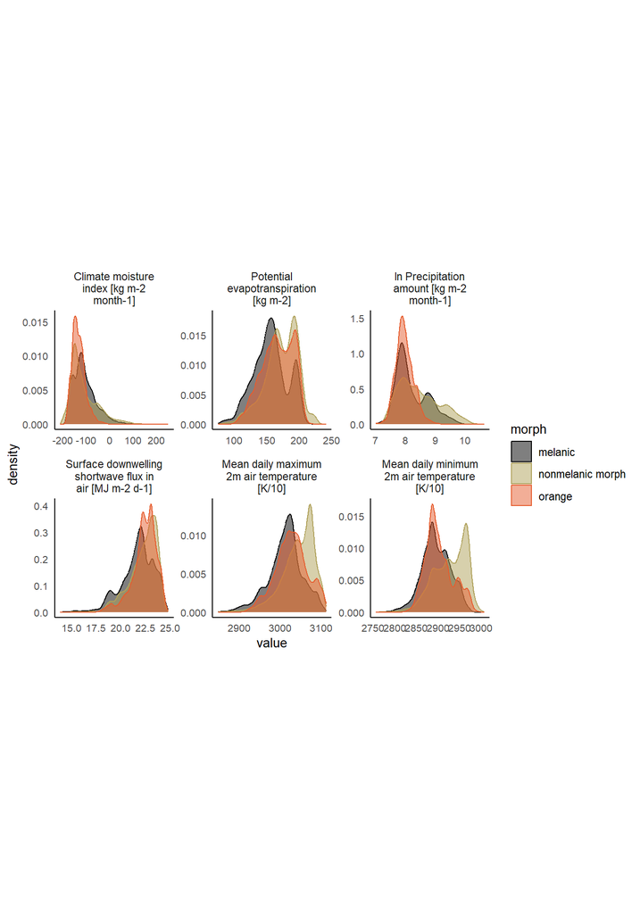

```r
ggplot() +
  # Add density plot for 'Prob' equal to 1
  geom_density(data = filter(plot_data, Prob == "0"),
               aes(x = value, color = morph,fill=morph)) +

  # Facet wrapping by 'variable' with customized labels
  facet_wrap(vars(fct_relevel(variable)),
             scales = "free",
             labeller = as_labeller(c(
               "chelsa_cmi" = str_wrap("Climate moisture index [kg m-2 month-1]", width = 20),
               "chelsa_pet" = str_wrap("Potential evapotranspiration [kg m-2]", width = 20),
               "chelsa_pr" = str_wrap("ln Precipitation amount [kg m-2 month-1]", width = 20),
               "chelsa_rsds" = str_wrap("Surface downwelling shortwave flux in air [MJ m-2 d-1]", width = 20),
               "chelsa_tasmax" = str_wrap("Mean daily maximum 2m air temperature [K/10]", width = 20),
               "chelsa_tasmin" = str_wrap("Mean daily minimum 2m air temperature [K/10]", width = 20)))) +

  # Manually set color values and labels
  scale_color_manual(values = colours,labels = c("melanic", "nonmelanic morph", "orange")) +
  scale_fill_manual(values = alpha(colours,0.5),labels = c("melanic", "nonmelanic morph", "orange"))+

  # Customize theme
  theme_classic() +
    theme(
    title = element_text(size = 10),
    strip.background = element_blank(),
    panel.background = element_blank(),
    panel.grid = element_blank(),
    axis.text = element_text(size = 8),
    axis.ticks = element_blank(),
    aspect.ratio = 1
  )
```

### AWAP data

create data for plotting on based on presence

```r
plot_data2<-pivot_longer(total_obs,cols = c("precipitation","vapor_pressure","max_temperature","min_temperature","solar_radiation"))
```

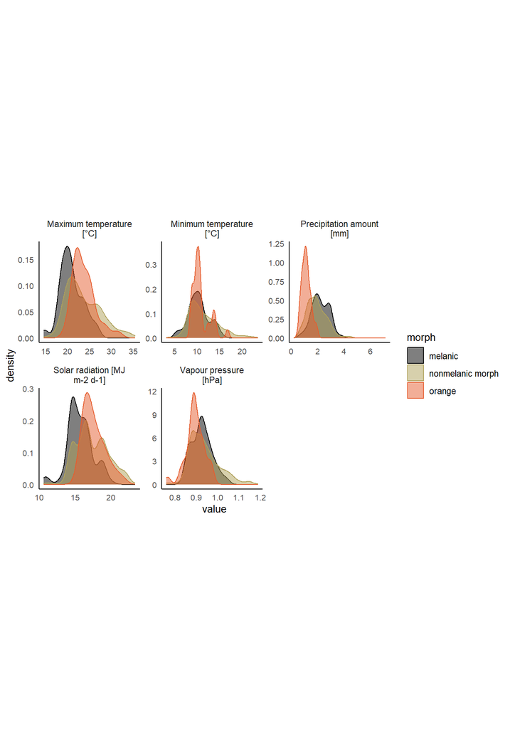

```r
# Define colors for morphs
o_col <- "#e65d2f"  # Orange color
w_col<-"#AFA15A"      # White color
b_col <- "black"     # Black color

# Create a vector of colors
colours <- c(b_col, w_col, o_col)

# Plotting using ggplot
ggplot() +
  # Add density plot for 'Prob' equal to 1
  geom_density(data = plot_data2,
               aes(x = value, color = morph,fill=morph)) +

  # Facet wrapping by 'variable' with customized labels
  facet_wrap(vars(fct_relevel(name)),
             scales = "free",
             labeller = as_labeller(c(
               "vapor_pressure" = str_wrap("Vapour pressure [hPa]", width = 20),
               "precipitation" = str_wrap("Precipitation amount [mm]", width = 20),
               "solar_radiation"= str_wrap("Solar radiation [MJ m-2 d-1]", width = 20),
               "max_temperature" = str_wrap("Maximum temperature [°C]", width = 20),
               "min_temperature" = str_wrap("Minimum temperature [°C]", width = 20)))) +

  # Manually set color values and labels
  scale_color_manual(values = colours,labels = c("melanic", "nonmelanic morph", "orange")) +
  scale_fill_manual(values = alpha(colours,0.5),labels = c("melanic", "nonmelanic morph", "orange"))+

  # Customize theme
  theme_classic() +
  theme(
    title = element_text(size = 10),
    strip.background = element_blank(),
    panel.background = element_blank(),
    panel.grid = element_blank(),
    axis.text = element_text(size = 8),
    axis.ticks = element_blank(),
    aspect.ratio = 1
  )
```

## Multivatriate analysis of climate niche divergence

visualizing the correlation of environmental variables in environemntal space

*amix_pca* is the PCA variable of the environmental variables sampled all color morphs occurrence points and at random background points.

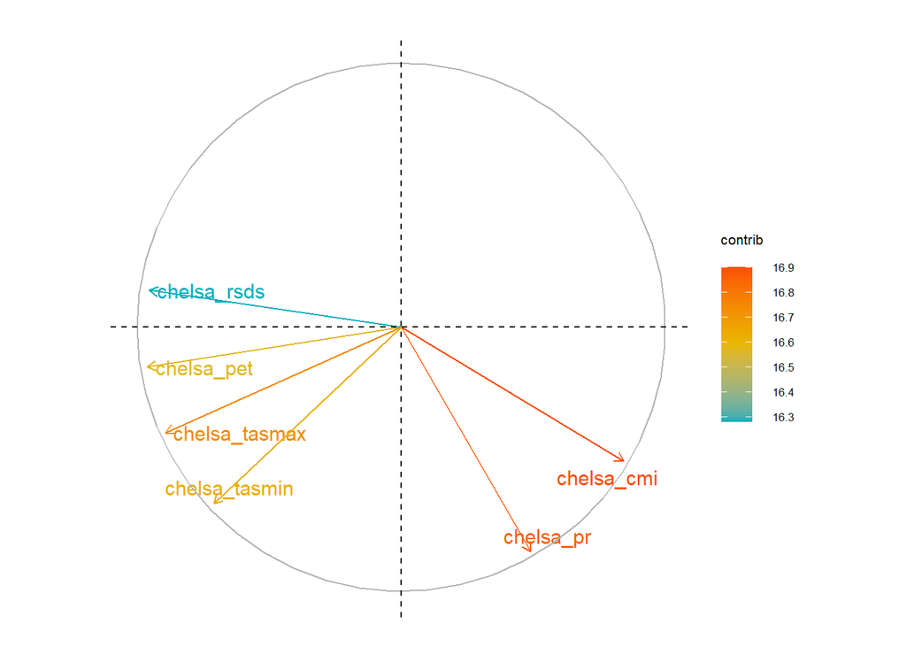

```r
amix_pca <- ade4::dudi.pca(rbind(nonmelanic_c,melanic_c,orange_c) %>%
         dplyr::select(-c(Longitude, Latitude, Prob)),
         scannf = F,
         nf = 7)
#save plot pca
#pdf("pca_variables_morphs.pdf")
factoextra::fviz_pca_var(amix_pca,
             repel = TRUE,col.var = "contrib",gradient.cols = c("#00AFBB", "#E7B800", "#FC4E07")) +
  labs(title = "") +
  scale_x_continuous(breaks = 0,
                     labels = "") +
  scale_y_continuous(breaks = 0,
                     labels = "") +
  theme(panel.background = element_blank(),
        panel.grid = element_blank(),
        axis.ticks = element_blank(),
        axis.title = element_blank(),
        text = element_text(size = unit(8, "mm")))
```

```r
#dev.off()
```

Position of environmental variables in environmental space defined by PC1 (X-axis) and PC2 (y-axis).

Contribution of each variable to the PCs

```r
loadings<-amix_pca$co

squared_loadings <- loadings^2

# Calculate total variance explained by each principal component
total_variance <- apply(squared_loadings, 2, sum)

contribution_pca1<-(squared_loadings[,1]) / total_variance[1]

names(contribution_pca1)<-rownames(squared_loadings)

contribution_pca2<-(squared_loadings[,2]) / total_variance[2]

names(contribution_pca2)<-rownames(squared_loadings)

contribution_pca1
```

```
##    chelsa_cmi    chelsa_pet     chelsa_pr   chelsa_rsds chelsa_tasmax
##    0.17336557    0.22624149    0.05888907    0.22302908    0.19506942
## chelsa_tasmin
##    0.12340535
```

```r
contribution_pca2
```

```
##    chelsa_cmi    chelsa_pet     chelsa_pr   chelsa_rsds chelsa_tasmax
##    0.15811607    0.01408977    0.44378129    0.01188238    0.09814640
## chelsa_tasmin
##    0.27398409
```

**Percent variation explained by PC axis**

```r
amix_eig <- 100 * amix_pca$eig/sum(amix_pca$eig)
amix_eig
```

```
## [1] 68.1389496 27.1823782  1.6748307  1.5017806  0.9587004  0.5433606
```

```r
cumsum(amix_eig)
```

```
## [1]  68.13895  95.32133  96.99616  98.49794  99.45664 100.00000
```

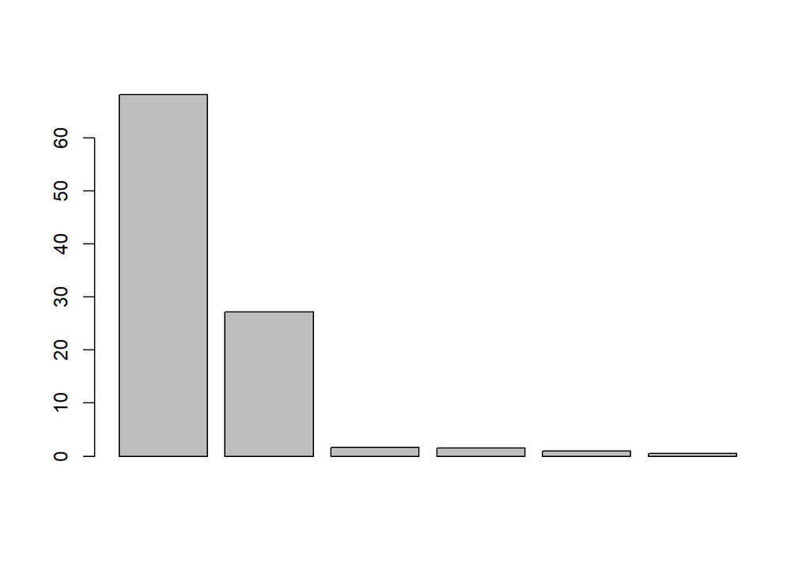

```r
barplot(amix_eig)
```

Load chelsa variables

```r
chelsa_variables <- raster::stack(list.files(path = "chelsea", pattern = ".tif", full.names = TRUE))

# Extract variable names from file names
names_variables <- list.files(path = "chelsea", pattern = ".tif$", full.names = TRUE) %>%
                    str_match(pattern = "\\w+.tif$") %>%
                    gsub(pattern = ".tif", replacement = "") %>%
                    as.vector()

# Assign descriptive names to the raster layers
names(chelsa_variables) <- paste0("chelsa_", names_variables)

chelsa_variables$chelsa_pr<-log(chelsa_variables$chelsa_pr)
```

### Climate nich divergence analysis under COUE (Centroid shift, Overlap, Unfilling and Expansion) framework with all the morphs.

Build the grids for each colour morph

```r
library(ecospat)

amix_globclim <- amix_pca$li
colnames(amix_globclim)<-names(chelsa_variables)
#scores of presences
nonmelanic_p_li <- ade4::suprow(amix_pca,nonmelanic_c[nonmelanic_c$Prob==1,4:length(nonmelanic_c)])$li
melanic_p_li <- ade4::suprow(amix_pca,melanic_c[melanic_c$Prob==1,4:length(melanic_c)])$li
orange_p_li <- ade4::suprow(amix_pca,orange_c[orange_c$Prob==1,4:length(orange_c)])$li

#scores of whole area
nonmelanic_all_li<- ade4::suprow(amix_pca,nonmelanic_c[,4:length(nonmelanic_c)])$li
melanic_all_li<- ade4::suprow(amix_pca,melanic_c[,4:length(melanic_c)])$li
orange_all_li<- ade4::suprow(amix_pca,orange_c[,4:length(orange_c)])$li

#gridding
nonmelanic_grid <- ecospat.grid.clim.dyn(glob = amix_globclim[1:2],
                                     glob1 = nonmelanic_all_li[1:2],
                                     sp = nonmelanic_p_li[1:2],
                                     R = 100,
                                     th.sp = 0)
melanic_grid <- ecospat.grid.clim.dyn(glob = amix_globclim[1:2],
                                    glob1 = melanic_all_li[1:2],
                                     sp = melanic_p_li[1:2],
                                     R = 100,
                                     th.sp = 0)
orange_grid <- ecospat.grid.clim.dyn(glob = amix_globclim[1:2],
                                     glob1 = orange_all_li[1:2],
                                     sp = orange_p_li[1:2],
                                     R = 100,
                                     th.sp = 0)
```

### Calculate niche expansion, stability and unfilling of the niche

```r
#melanic vs nonmelanic

amix_niche_dyn_BvW <- ecospat.niche.dyn.index (nonmelanic_grid,
                                               melanic_grid,
                                               intersection = 0.05)
amix_niche_dyn_BvW$dynamic.index.w
```

```
##    expansion    stability    unfilling
## 0.0003400483 0.9996599517 0.1697865153
```

```r
#melanic vs orange

amix_niche_dyn_BvO <- ecospat.niche.dyn.index (orange_grid,
                                               melanic_grid,
                                               intersection = 0.05)
amix_niche_dyn_BvO$dynamic.index.w
```

```
## expansion stability unfilling
## 0.3979740 0.6020260 0.1130559
```

```r
#nonmelanic vs orange

amix_niche_dyn_WvO <- ecospat.niche.dyn.index (nonmelanic_grid,
                                               orange_grid,
                                               intersection = 0.05)
amix_niche_dyn_WvO$dynamic.index.w
```

```
## expansion stability unfilling
## 0.0000000 1.0000000 0.3525656
```

### Visualizing niche differences

```r
#pdf("plots/nonmelanic_melanic_nichedym.pdf",width=20,height=20)

#with z.uncor being the density of occurrence of the species, and z.cor the occupancy of the environment by the species


# the plot is based on rasters, modify accordingly!
nonmelanic <- as.data.frame(nonmelanic_grid$z.uncor, xy = TRUE) %>%
  rename(z = lyr.1) %>% mutate(morph="nonmelanic")

melanic <- as.data.frame(melanic_grid$z.uncor, xy = TRUE) %>%
  rename(z = lyr.1) %>% mutate(morph="melanic")

orange <- as.data.frame(orange_grid$z.uncor, xy = TRUE) %>%
  rename(z = lyr.1) %>% mutate(morph="orange")

total_presence<-rbind(nonmelanic,melanic,orange)

#presence values of PCA1 and PCA2

orange_li<-orange_p_li[1:2] %>% mutate(morph="orange")
nonmelanic_li<-nonmelanic_p_li[1:2] %>% mutate(morph="nonmelanic")
melanic_li<-nonmelanic_p_li[1:2] %>% mutate(morph="melanic")

all_li<-rbind(orange_li,nonmelanic_li,melanic_li)
o_col<-"#e65d2f"
w_col<-"#AFA15A"
b_col<-"black"
```

#### Discarding rare occurrences based on spacial density

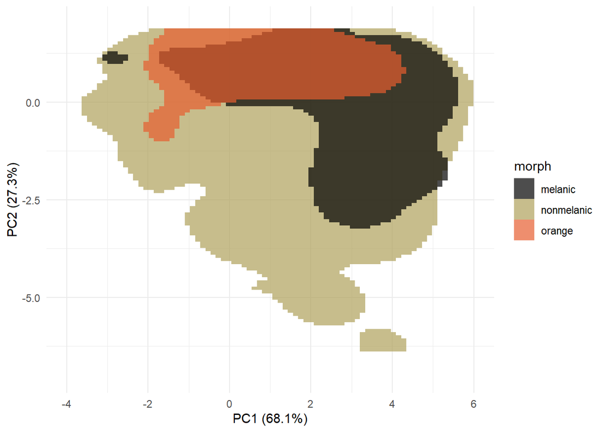

```r
ggplot(total_presence %>% filter(z>0), aes(x = x, y = y, fill = morph)) +
  geom_tile() +
  scale_fill_manual(values = c("melanic" = alpha(b_col,0.7),"nonmelanic" = alpha(w_col,0.7), "orange" = alpha(o_col,0.7)))+ylim(c(-7,2))+xlim(-4,6)+
  theme_minimal()+labs(x="PC1 (68.1%)",y="PC2 (27.3%)")
```

#### All the enviromental space for the morphs based on occupied ecoregions

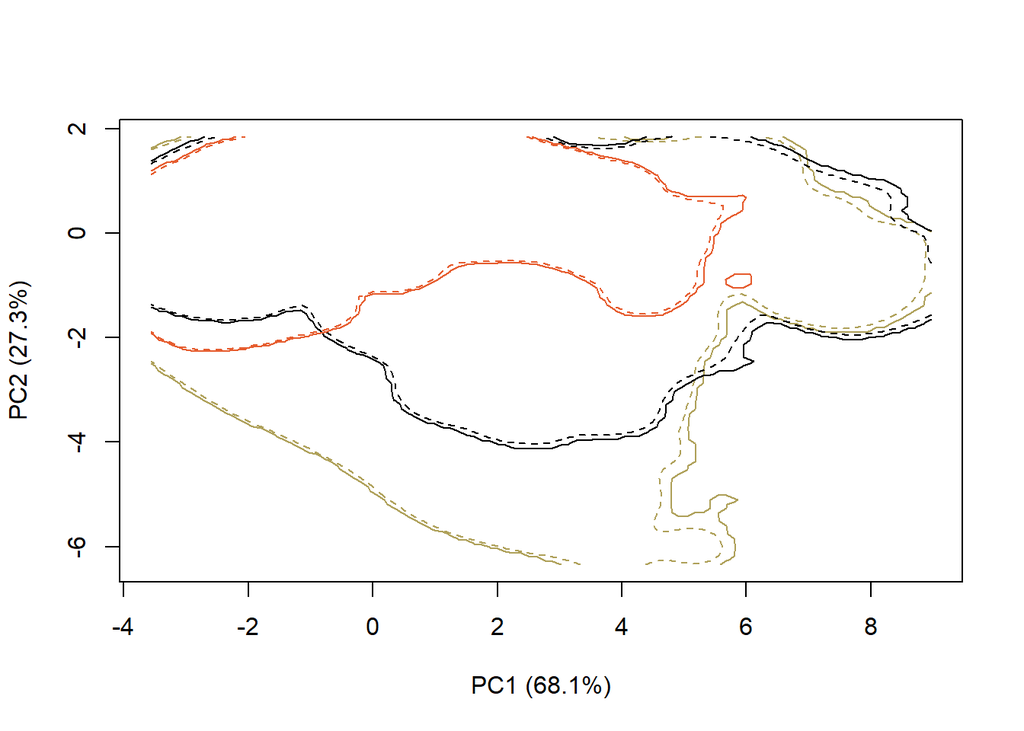

```r
quant<-0.05

plot(NA, xlim = c(min(total_presence$x),max(total_presence$x)), ylim = c(min(total_presence$y),max(total_presence$y)), xlab = "PC1 (68.1%)", ylab = "PC2 (27.3%)")

terra::contour(nonmelanic_grid$Z, add = TRUE, levels = quantile(nonmelanic_grid$Z[nonmelanic_grid$Z >0], c(0, quant)), drawlabels = FALSE, lty = c(1,2),col=w_col)

terra::contour(melanic_grid$Z, add = TRUE, levels = quantile(melanic_grid$Z[melanic_grid$Z >0], c(0, quant)), drawlabels = FALSE, lty = c(1,2),col=b_col)

terra::contour(orange_grid$Z, add = TRUE, levels = quantile(orange_grid$Z[orange_grid$Z >0], c(0, quant)), drawlabels = FALSE, lty = c(1,2),col=o_col)
```

#### pairwise comparison using density of ocurrences

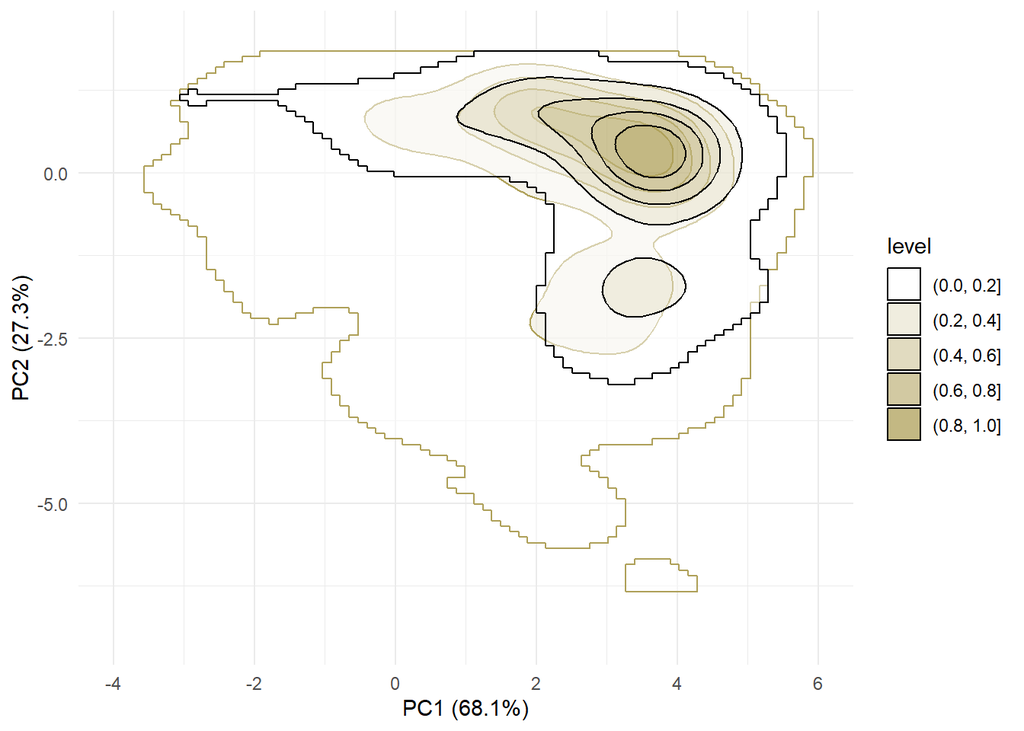

```r
paleta_w<-colorRampPalette(c("white",w_col))
paleta_o<-colorRampPalette(c("white",o_col))
paleta_b<-colorRampPalette(c("white",b_col))

# melanic vs orange
ggplot() +
  geom_contour_filled(data = total_presence %>% filter(z > 0. & morph == "nonmelanic"), aes(x = x, y = y, z = z), color = w_col, alpha = 0.5, bins = 5) +
  scale_fill_manual(values = alpha(paleta_w(5), 0.7))+geom_contour_filled(data = total_presence %>% filter(z > 0 & morph == "melanic"), aes(x = x, y = y, z = z), color = b_col, alpha = 0.5, bins = 5) +
  scale_fill_manual(values = alpha(c(paleta_w(5),paleta_b(5)), 0.7))+ylim(c(-7,2))+xlim(-4,6)+
  theme_minimal()+labs(x="PC1 (68.1%)",y="PC2 (27.3%)")+theme_minimal()
```

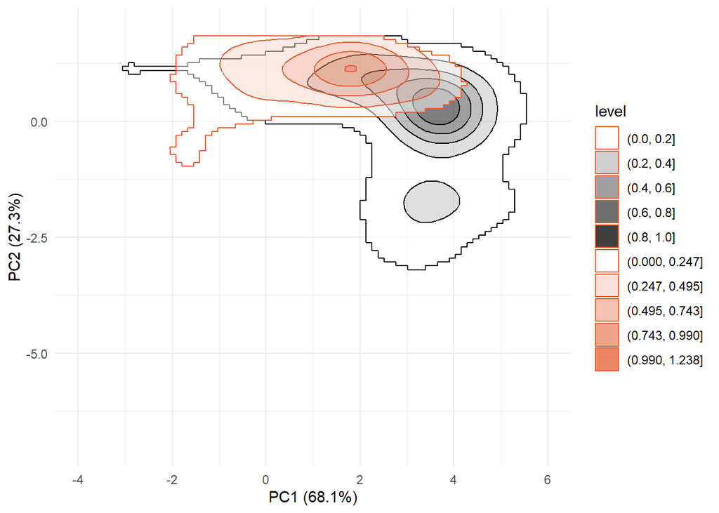

```r
# melanic vs orange
ggplot() +
  geom_contour_filled(data = total_presence %>% filter(z > 0. & morph == "melanic"), aes(x = x, y = y, z = z), color = b_col, alpha = 0.5, bins = 5) +
  scale_fill_manual(values = alpha(paleta_w(5), 0.7))+geom_contour_filled(data = total_presence %>% filter(z > 0 & morph == "orange"), aes(x = x, y = y, z = z), color = o_col, alpha = 0.5, bins = 5) +
  scale_fill_manual(values = alpha(c(paleta_b(5),paleta_o(5)), 0.7))+ylim(c(-7,2))+xlim(-4,6)+
  theme_minimal()+labs(x="PC1 (68.1%)",y="PC2 (27.3%)")+theme_minimal()
```

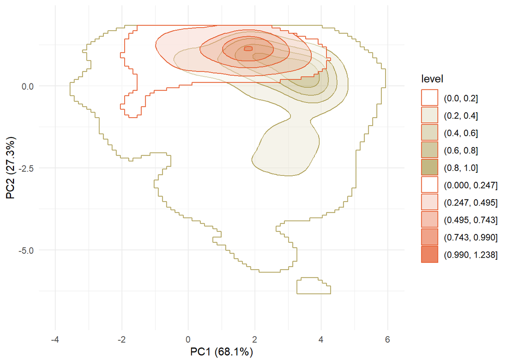

```r
# nonmelanic vs orange
ggplot() +
  geom_contour_filled(data = total_presence %>% filter(z > 0. & morph == "nonmelanic"), aes(x = x, y = y, z = z), color = w_col, alpha = 0.5, bins = 5) +
  scale_fill_manual(values = alpha(paleta_w(5), 0.7))+geom_contour_filled(data = total_presence %>% filter(z > 0 & morph == "orange"), aes(x = x, y = y, z = z), color = o_col, alpha = 0.5, bins = 5) +
  scale_fill_manual(values = alpha(c(paleta_w(5),paleta_o(5)), 0.7))+ylim(c(-7,2))+xlim(-4,6)+
  theme_minimal()+labs(x="PC1 (68.1%)",y="PC2 (27.3%)")+theme_minimal()
```

## Visualising the distribution of values and overalp environmental variables comparing morphs in pairs .

**From here you need to compare morphs per pairs**

### Melanic vs non-melanic

#### Schoenner’s D index of niche overlap

```r
ecospat.niche.overlap(nonmelanic_grid,
                      melanic_grid,
                      cor = T)$D
```

```
## [1] 0.6480636
```

#### Hellinger distance I

```r
ecospat.niche.overlap(nonmelanic_grid,
                      melanic_grid,
                      cor = T)$I
```

```
## [1] 0.8227404
```

#### Niche equivalency

**Under niche conservatism** Niche equivalency test H0: niche overlap is equivalent to the random distribution

Niche equivalency test H1: the observed overlap between A and B niche is higher than if the two niches are randomized

**Under niche divergence** Niche divergence test H0: niche overlap is equivalent to the random distribution

Niche divergence test H1: the observed overlap between A and B niche is lower than if the two niches are randomized

```r
eq_test_divergence <- ecospat.niche.equivalency.test(nonmelanic_grid,melanic_grid,rep=1000,overlap.alternative="lower")

eq_test_conservatism <- ecospat.niche.equivalency.test(nonmelanic_grid,melanic_grid,rep=1000,overlap.alternative="higher")
```

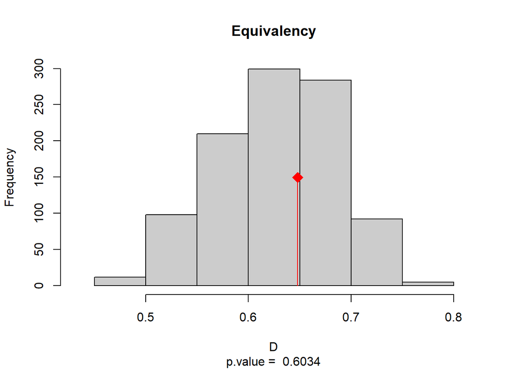

```r
ecospat.plot.overlap.test(eq_test_divergence, "D", "Equivalency")
```

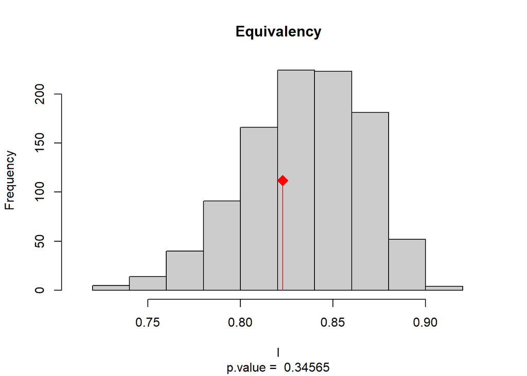

```r
ecospat.plot.overlap.test(eq_test_divergence, "I", "Equivalency")
```

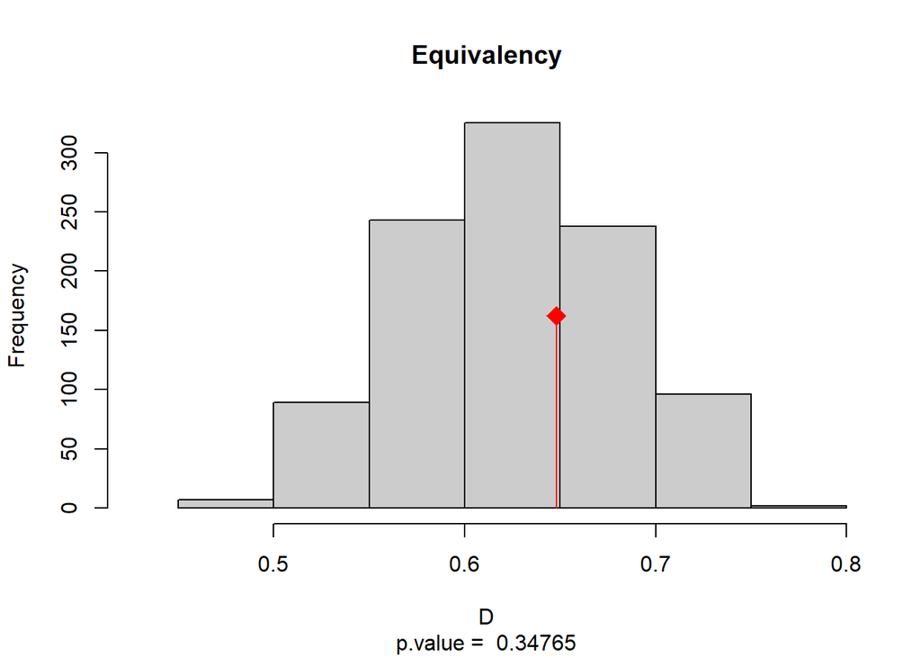

```r
ecospat.plot.overlap.test(eq_test_conservatism, "D", "Equivalency")
```

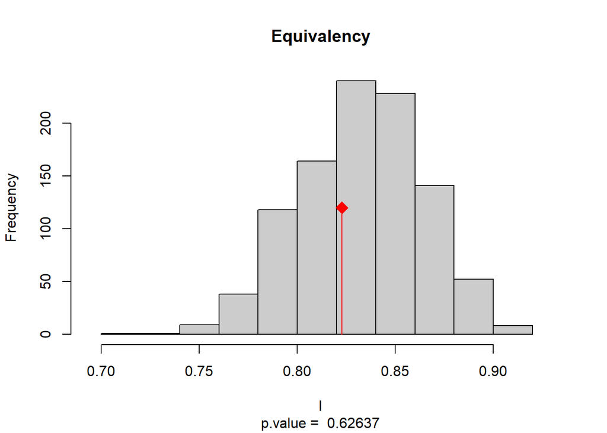

```r
ecospat.plot.overlap.test(eq_test_conservatism, "I", "Equivalency")
```

#### Niche similarity test

**Under niche conservatism** Niche equivalency test H0: niche overlap is similar to the random distribution

Niche equivalency test H1: the observed overlap between A and B niche is higher than if the two niches are randomized

**Under niche divergence** Niche divergence test H0: niche overlap is similar to the random distribution

Niche divergence test H1: the observed overlap between A and B niche is lower than if the two niches are randomized

```r
sim_test_1_cons <- ecospat.niche.similarity.test(nonmelanic_grid,
                                          melanic_grid,
                                          rep=1000,
                                          overlap.alternative = "higher",
                                          rand.type=1)
sim_test_2_cons <- ecospat.niche.similarity.test(melanic_grid,
                                            nonmelanic_grid,
                                          rep=1000,
                                          overlap.alternative = "higher",
                                          rand.type=1)
```

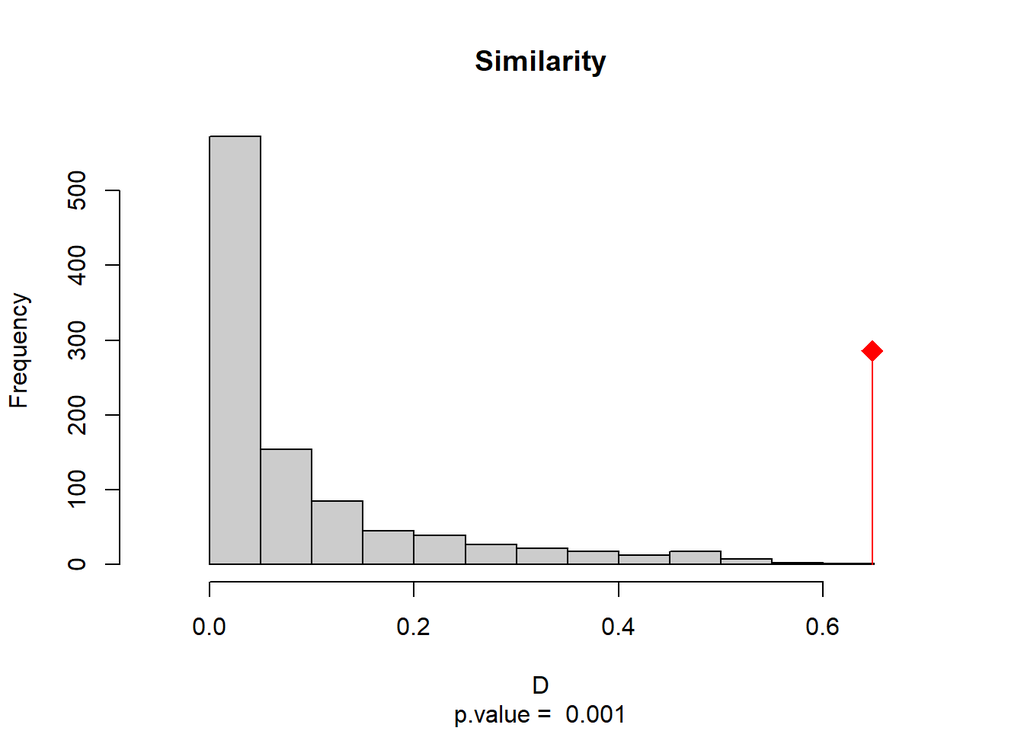

```r
ecospat.plot.overlap.test(sim_test_1_cons, "D", "Similarity")
```

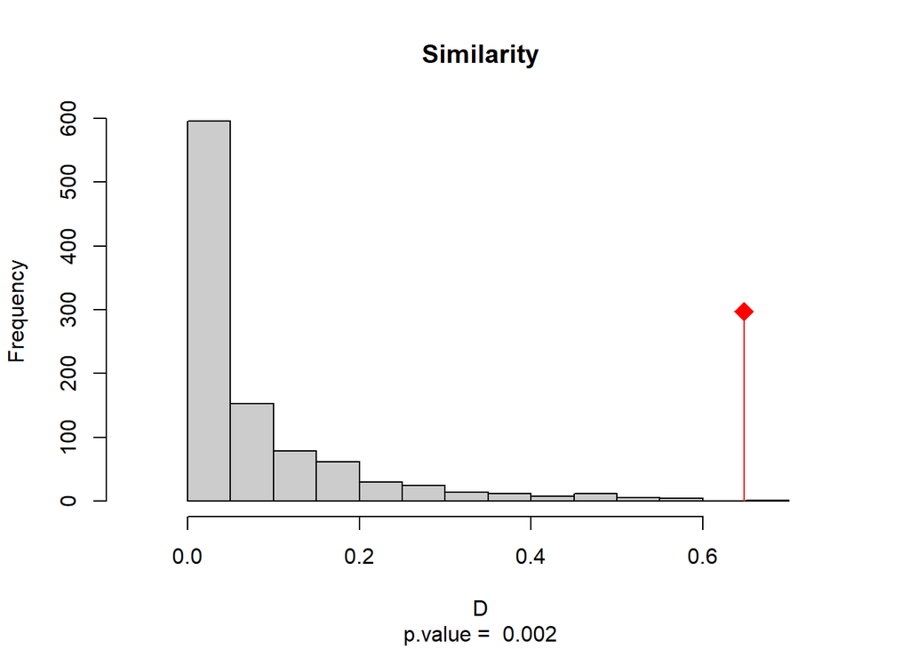

```r
ecospat.plot.overlap.test(sim_test_2_cons, "D", "Similarity")
```

```r
sim_test_1_div <- ecospat.niche.similarity.test(nonmelanic_grid,
                                          melanic_grid,
                                          rep=1000,
                                          overlap.alternative = "lower",
                                          rand.type=1)
sim_test_2_div <- ecospat.niche.similarity.test(melanic_grid,
                                            nonmelanic_grid,
                                          rep=1000,
                                          overlap.alternative = "lower",
                                          rand.type=1)
```

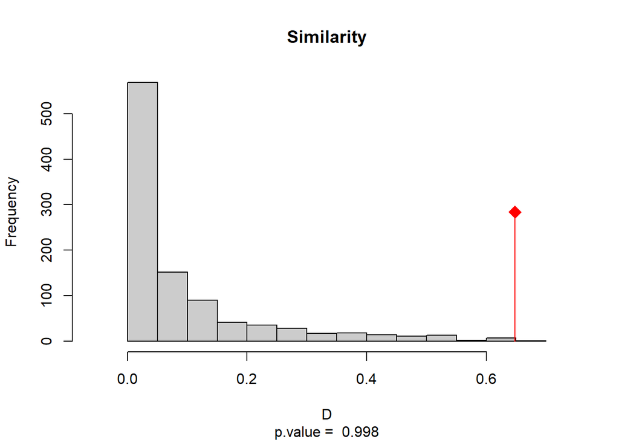

```r
ecospat.plot.overlap.test(sim_test_1_div, "D", "Similarity")
```

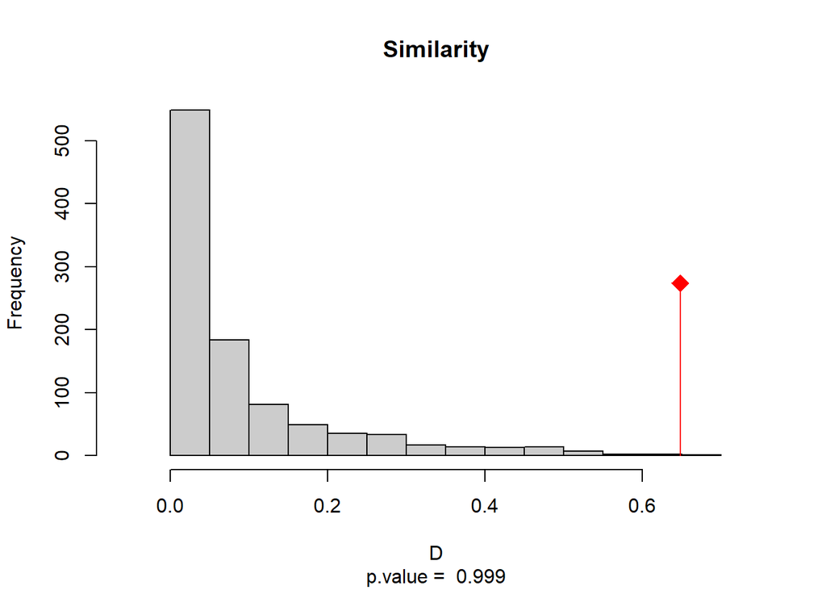

```r
ecospat.plot.overlap.test(sim_test_2_div, "D", "Similarity")
```

### Melanic vs orange

#### Schoenner’s D index of niche overlap

```r
ecospat.niche.overlap(orange_grid,
                      melanic_grid,
                      cor = T)$D
```

```
## [1] 0.250374
```

#### Hellinger distance I

```r
ecospat.niche.overlap(orange_grid,
                      melanic_grid,
                      cor = T)$I
```

```
## [1] 0.4580084
```

#### Niche equivalency

**Under niche conservatism** Niche equivalency test H0: niche overlap is equivalent to the random distribution

Niche equivalency test H1: the observed overlap between A and B niche is higher than if the two niches are randomized

**Under niche divergence** Niche divergence test H0: niche overlap is equivalent to the random distribution

Niche divergence test H1: the observed overlap between A and B niche is lower than if the two niches are randomized

```r
eq_test_divergence <- ecospat.niche.equivalency.test(orange_grid,melanic_grid,rep=1000,overlap.alternative="lower")

eq_test_conservatism <- ecospat.niche.equivalency.test(orange_grid,melanic_grid,rep=1000,overlap.alternative="higher")
```

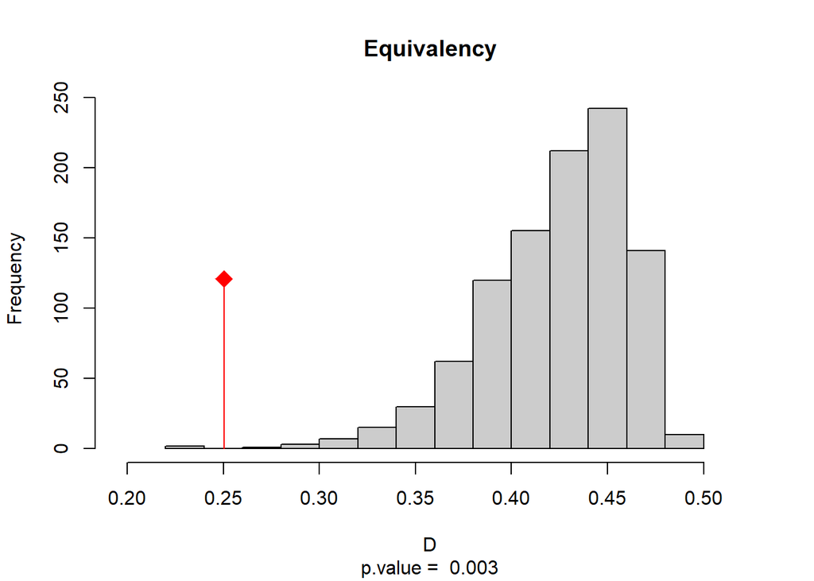

```r
ecospat.plot.overlap.test(eq_test_divergence, "D", "Equivalency")
```

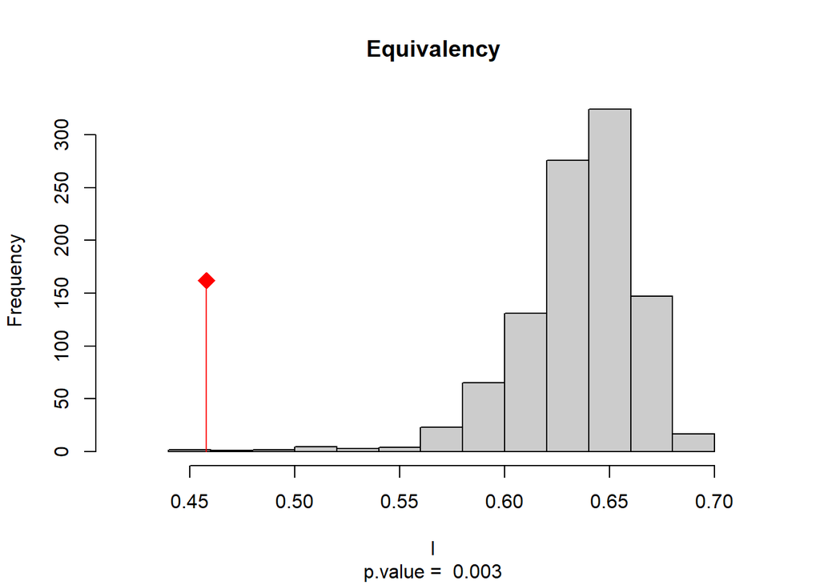

```r
ecospat.plot.overlap.test(eq_test_divergence, "I", "Equivalency")
```

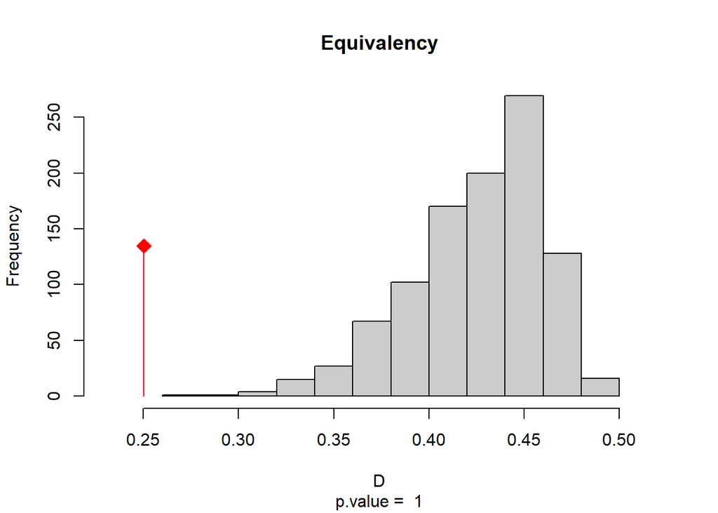

```r
ecospat.plot.overlap.test(eq_test_conservatism, "D", "Equivalency")
```

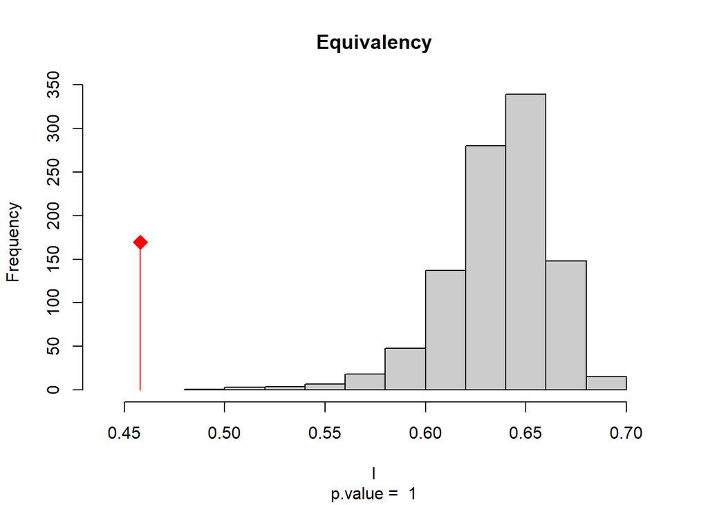

```r
ecospat.plot.overlap.test(eq_test_conservatism, "I", "Equivalency")
```

#### Niche similarity test

**Under niche conservatism** Niche equivalency test H0: niche overlap is similar to the random distribution

Niche equivalency test H1: the observed overlap between A and B niche is higher than if the two niches are randomized

**Under niche divergence** Niche divergence test H0: niche overlap is similar to the random distribution

Niche divergence test H1: the observed overlap between A and B niche is lower than if the two niches are randomized

```r
sim_test_1_cons <- ecospat.niche.similarity.test(orange_grid,
                                          melanic_grid,
                                          rep=1000,
                                          overlap.alternative = "higher",
                                          rand.type=1)
sim_test_2_cons <- ecospat.niche.similarity.test(melanic_grid,
                                            orange_grid,
                                          rep=1000,
                                          overlap.alternative = "higher",
                                          rand.type=1)
```

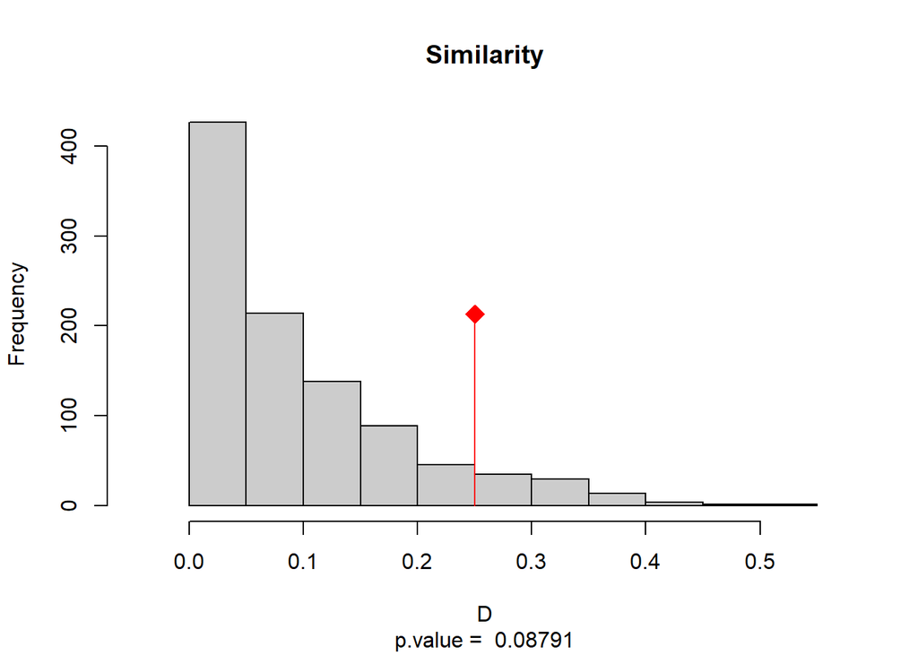

```r
ecospat.plot.overlap.test(sim_test_1_cons, "D", "Similarity")
```

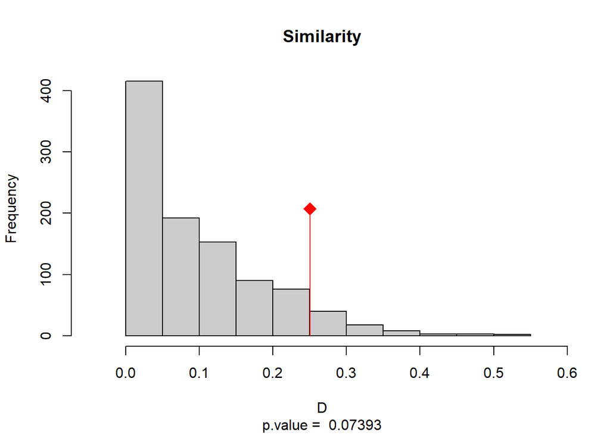

```r
ecospat.plot.overlap.test(sim_test_2_cons, "D", "Similarity")
```

```r
sim_test_1_div <- ecospat.niche.similarity.test(orange_grid,
                                          melanic_grid,
                                          rep=1000,
                                          overlap.alternative = "lower",
                                          rand.type=1)
sim_test_2_div <- ecospat.niche.similarity.test(melanic_grid,
                                            orange_grid,
                                          rep=1000,
                                          overlap.alternative = "lower",
                                          rand.type=1)
```

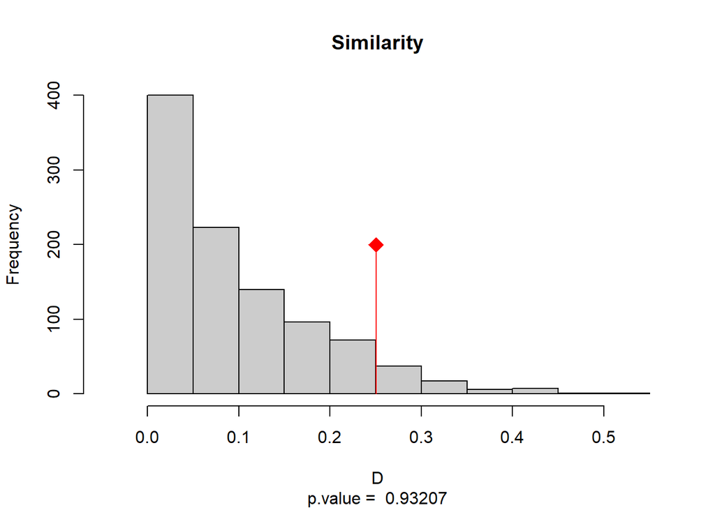

```r
ecospat.plot.overlap.test(sim_test_1_div, "D", "Similarity")
```

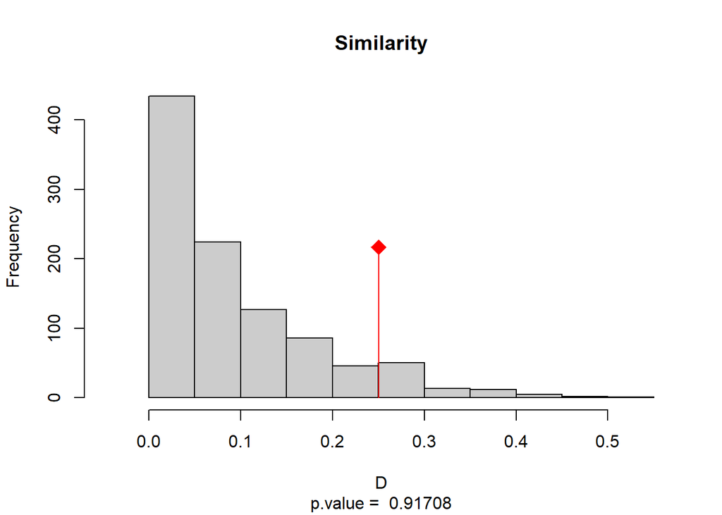

```r
ecospat.plot.overlap.test(sim_test_2_div, "D", "Similarity")
```